# Basic Inferential Data Analysis

### Data Loading and Exploratory Analysis

```r
data("ToothGrowth")
head(ToothGrowth)
```

```
##    len supp dose
## 1  4.2   VC  0.5
## 2 11.5   VC  0.5
## 3  7.3   VC  0.5
## 4  5.8   VC  0.5
## 5  6.4   VC  0.5
## 6 10.0   VC  0.5
```

We perform the following exploratory analysis which clearly suggests that Dosage has a clear effect on odontoblast level.

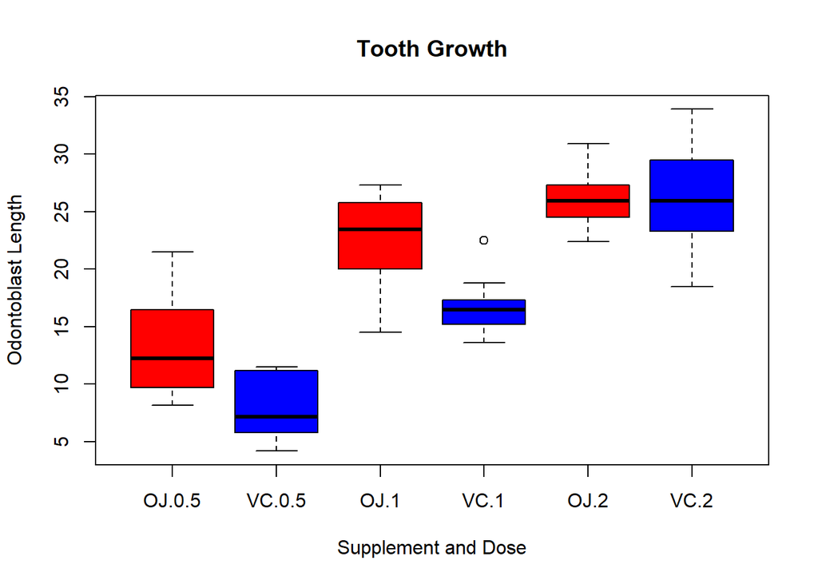

```r
boxplot(len~supp+dose, data=ToothGrowth, notch=FALSE,
  col=(c("red","blue")),
  main="Tooth Growth", xlab="Supplement and Dose", ylab = "Odontoblast Length")
```

The following is a summary of the ToothGrowth data:

```r
summary(ToothGrowth)
```

```
##       len        supp         dose
##  Min.   : 4.20   OJ:30   Min.   :0.500
##  1st Qu.:13.07   VC:30   1st Qu.:0.500
##  Median :19.25           Median :1.000
##  Mean   :18.81           Mean   :1.167
##  3rd Qu.:25.27           3rd Qu.:2.000
##  Max.   :33.90           Max.   :2.000
```

### Confidence Intervals

An interesting question is whether Supplement has any effect on odontoblast level. We investigate to see if one Supplement is more effective than another. We perform a t-test against the two different supplement groups to compare their sample means. We use a t-test, rather than a normal test since since we do not know the population variance.

```r
r2 <- t.test(len~supp, paired=F, data=ToothGrowth)
r2$p.value
```

```
## [1] 0.06063451
```

```r
r2$conf.int
```

```
## [1] -0.1710156  7.5710156
## attr(,"conf.level")
## [1] 0.95
```

The p-value shows that the test is not statistically significant at the 5% level.

### Conclusion

We have assumed an uneven variance between the two groups of supplements and a two sided 5%- significance level. The t-test suggests that there is not enough evidence to reject the null hypothesis of the two supplements having the same effect. Visually, we can see that high dosages cause the odontoblasts to grow longer.